# 418 Homework 3

Jordan Berninger - 304872549

5/23/2017

$\textbf{Introduction to MoMA Collection dataset}$

I chose to analyze the Museum of Modern Art Collection dataset from Kaggle (https://www.kaggle.com/momanyc/museum-collection). There were two files in this dataset, artists and artworks. I joined the datasets on a shared variable (Artist.ID) and decided to model artist gender from the following variables.

```r
colnames(art.art)
```

```
## [1] "Gender"           "Date"             "Credit"
## [4] "Catalogue"        "Acquisition.Date" "Department"
## [7] "Nationality"      "Birth.Year"       "Death.Status"
```

To clean the data, I had to manipulate the Gender variable into a factor. I noticed that there were many artworks that had a blank for the artist gender. I assumed that these were pieces produced by groups, or non-binary gender artists. For the sake of simplicity and assignment constraints, I removed null gender values, so each artwork in the dataset was associated with either a Male or Femla artist. It was also necessary to do some transformation on the several Date, Acquisition.Date, Birth.Year, and Death.Year columns. They had different structures in the raw data so I converted them accordingly. I chose to create Death.Status as a boolean variable. After removing incolplete rows, I was left with the following cleaned dataset.

```r
str(art.art)
```

```
## 'data.frame':    88670 obs. of  9 variables:
##  $ Gender          : Factor w/ 2 levels "0","1": 2 2 1 2 2 2 2 2 2 2 ...
##  $ Date            : Date, format: "1977-05-24" "1986-05-24" ...
##  $ Credit          : Factor w/ 7031 levels "","[Misc.] Gift of The Judith Rothschild Foundation",..: 5046 2917 5726 5868 1987 6391 5725 5351 5351 5351 ...
##  $ Catalogue       : Factor w/ 2 levels "N","Y": 2 2 2 2 2 2 2 1 1 1 ...
##  $ Acquisition.Date: Date, format: "1981-04-28" "1997-05-28" ...
##  $ Department      : Factor w/ 9 levels "Architecture & Design",..: 3 9 9 9 7 9 7 8 8 8 ...
##  $ Nationality     : Factor w/ 126 levels "","Afghan","Albanian",..: 5 5 5 5 5 5 5 43 43 43 ...
##  $ Birth.Year      : int  1930 1930 1918 1897 1897 1897 1897 1908 1908 1908 ...
##  $ Death.Status    : Factor w/ 2 levels "0","1": 2 2 1 2 2 2 2 2 2 2 ...
##  - attr(*, "na.action")=Class 'omit'  Named int [1:27502] 8 9 47 81 98 152 250 282 337 361 ...
##   .. ..- attr(*, "names")= chr [1:27502] "8" "9" "47" "81" ...
```

```r
summary(art.art)
```

```
##  Gender         Date
##  0:12301   Min.   :0001-05-24
##  1:76369   1st Qu.:1932-05-24
##            Median :1964-05-24
##            Mean   :1956-10-16
##            3rd Qu.:1983-05-24
##            Max.   :2017-05-24
##
##                                                        Credit
##  The Louis E. Stern Collection                            :10226
##  Purchase                                                 : 6053
##  Gift of the artist                                       : 5926
##  Abbott-Levy Collection. Partial gift of Shirley C. Burden: 4487
##  Gift of the photographer                                 : 2408
##                                                           : 1866
##  (Other)                                                  :57704
##  Catalogue Acquisition.Date                          Department
##  N:39625   Min.   :1929-11-19   Prints & Illustrated Books:45161
##  Y:49045   1st Qu.:1964-10-06   Photography               :21361
##            Median :1981-02-26   Architecture & Design     : 8174
##            Mean   :1983-08-19   Drawings                  : 6354
##            3rd Qu.:2005-05-10   Painting & Sculpture      : 3246
##            Max.   :2016-12-15   Media and Performance Art : 2093
##                                 (Other)                   : 2281
##    Nationality      Birth.Year   Death.Status
##  American:39547   Min.   :1730   0:31582
##  French  :18996   1st Qu.:1887   1:57088
##  German  : 5612   Median :1918
##  British : 4267   Mean   :1912
##  Spanish : 2246   3rd Qu.:1939
##  Italian : 2137   Max.   :2000
##  (Other) :15865
```

Before running any models, I produced a lot of plots and summary statistics to familiarize myself with the data. I thought this plot was interesting:

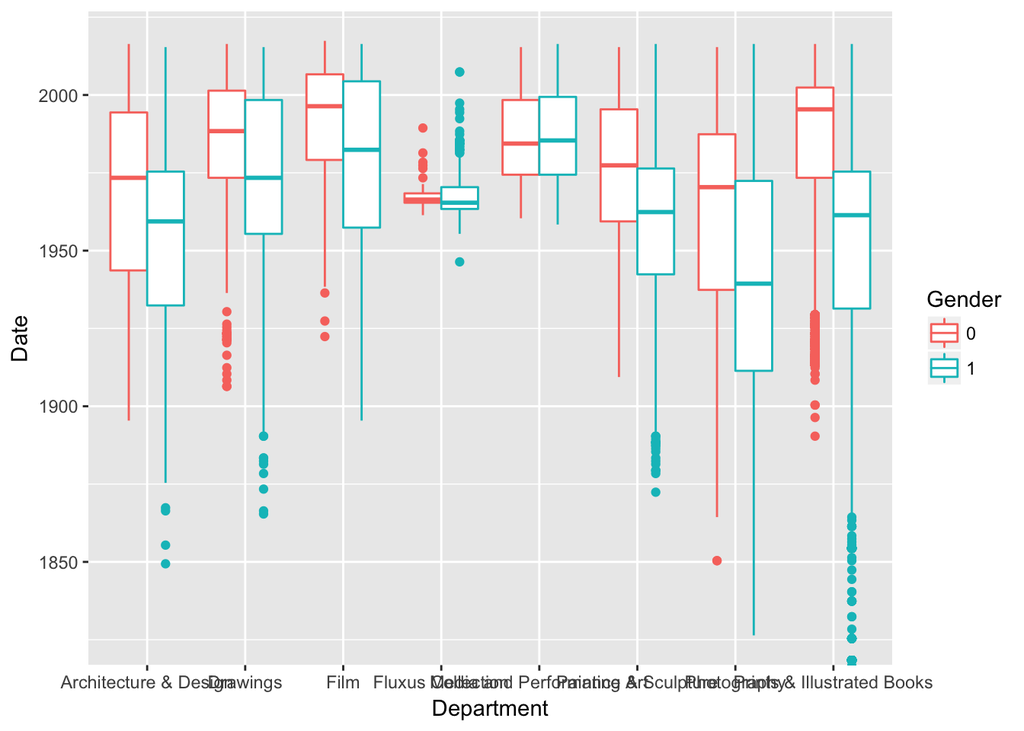

```r
ggplot(art.art, aes(x=Department, y=Date, color=Gender)) + geom_boxplot()
```

The data was randomly divided into training and test sets, with the training set representing 60% of the data. We will compare the performance of each model on the two data sets, where possible.

$\textbf{Logistic Regression with Lasso Regularization}$

$\textbf{glmnet}$

```
##    user  system elapsed
## 751.970   4.614 763.579
```

```
## [1] 0.5
```

First, I used the glmnet package. I trained the model on the training set, and I gave it a lambda value of .5. This model took quite a bit of time for this model to train. The AUC performance on the test data was .5.